# Trabajo Grupal: Teoría de la Decisión - Soluciones

Author

Carmen Márquez Sobrino, Adrián Avelino Martín, Gabriele Amorese

# Introducción y Carga de Funciones

En este documento se presenta la resolución completa de los dos problemas de decisión bajo Incertidumbre propuestos.

```r
source("teoriadecision_funciones_incertidumbre.R")
library(knitr)
```

# Problema 1: Matriz de Decisión

Definimos la matriz de decisión del **Problema 1**:

```r
vec_p1 = c(10, 15, 7,
            4, 20, 12,
            8,  8, 18,
           12,  6, 14)

tb01 = crea.tablaX(vec_p1,
                   numalternativas = 4,
                   numestados = 3,
                   nb_alternativas = c("d1", "d2", "d3", "d4"),
                   nb_estados = c("e1", "e2", "e3"))

kable(tb01, caption = "Matriz de Decisiones - Problema 1")
```

Matriz de Decisiones - Problema 1

|  | e1 | e2 | e3 |
| --- | --- | --- | --- |
| d1 | 10 | 15 | 7 |
| d2 | 4 | 20 | 12 |
| d3 | 8 | 8 | 18 |
| d4 | 12 | 6 | 14 |

## Resolución en Situación Favorable (Beneficios)

A continuación resolvemos el problema mediante las funciones individuales del script para situación favorable:

```r
# 1. Criterio Pesimista (Wald)
res_wald_fav <- criterio.Wald(tb01, favorable = TRUE)
res_wald_fav
```

```
$criterio
[1] "Wald"

$metodo
[1] "favorable"

$tablaX
   e1 e2 e3
d1 10 15  7
d2  4 20 12
d3  8  8 18
d4 12  6 14

$ValorAlternativas
d1 d2 d3 d4
 7  4  8  6

$ValorOptimo
[1] 8

$AlternativaOptima
d3
 3
```

```r
# 2. Criterio Optimista
res_opt_fav <- criterio.Optimista(tb01, favorable = TRUE)
res_opt_fav
```

```
$criterio
[1] "Optimista"

$metodo
[1] "favorable"

$tablaX
   e1 e2 e3
d1 10 15  7
d2  4 20 12
d3  8  8 18
d4 12  6 14

$ValorAlternativas
d1 d2 d3 d4
15 20 18 14

$ValorOptimo
[1] 20

$AlternativaOptima
d2
 2
```

```r
# 3. Criterio de Hurwicz (alfa = 0.4)
res_hurwicz_fav <- criterio.Hurwicz(tb01, alfa = 0.4, favorable = TRUE)
res_hurwicz_fav
```

```
$criterio
[1] "Hurwicz"

$alfa
[1] 0.4

$metodo
[1] "favorable"

$tablaX
   e1 e2 e3
d1 10 15  7
d2  4 20 12
d3  8  8 18
d4 12  6 14

$ValorAlternativas
  d1   d2   d3   d4
10.2 10.4 12.0  9.2

$ValorOptimo
[1] 12

$AlternativaOptima
d3
 3
```

```r
# 4. Criterio de Savage
res_savage_fav <- criterio.Savage(tb01, favorable = TRUE)
res_savage_fav
```

```
$criterio
[1] "Savage"

$metodo
[1] "favorable"

$tablaX
   e1 e2 e3
d1 10 15  7
d2  4 20 12
d3  8  8 18
d4 12  6 14

$Mejores
e1 e2 e3
12 20 18

$Pesos
   e1 e2 e3
d1  2  5 11
d2  8  0  6
d3  4 12  0
d4  0 14  4

$ValorAlternativas
d1 d2 d3 d4
11  8 12 14

$ValorOptimo
[1] 8

$AlternativaOptima
d2
 2
```

```r
# 5. Criterio de Laplace
res_laplace_fav <- criterio.Laplace(tb01, favorable = TRUE)
res_laplace_fav
```

```
$criterio
[1] "Laplace"

$metodo
[1] "favorable"

$tablaX
   e1 e2 e3
d1 10 15  7
d2  4 20 12
d3  8  8 18
d4 12  6 14

$ValorAlternativas
      d1       d2       d3       d4
10.66667 12.00000 11.33333 10.66667

$ValorOptimo
[1] 12

$AlternativaOptima
d2
 2
```

```r
# 6. Criterio del Punto Ideal
res_pi_fav <- criterio.PuntoIdeal(tb01, favorable = TRUE)
res_pi_fav
```

```
$criterio
[1] "Punto Ideal"

$metodo
[1] "favorable"

$tablaX
   e1 e2 e3
d1 10 15  7
d2  4 20 12
d3  8  8 18
d4 12  6 14

$Mejores
e1 e2 e3
12 20 18

$ValorAlternativas
      d1       d2       d3       d4
12.24745 10.00000 12.64911 14.56022

$ValorOptimo
[1] 10

$AlternativaOptima
d2
 2
```

### Análisis de Intervalos del Criterio de Hurwicz (Favorable)

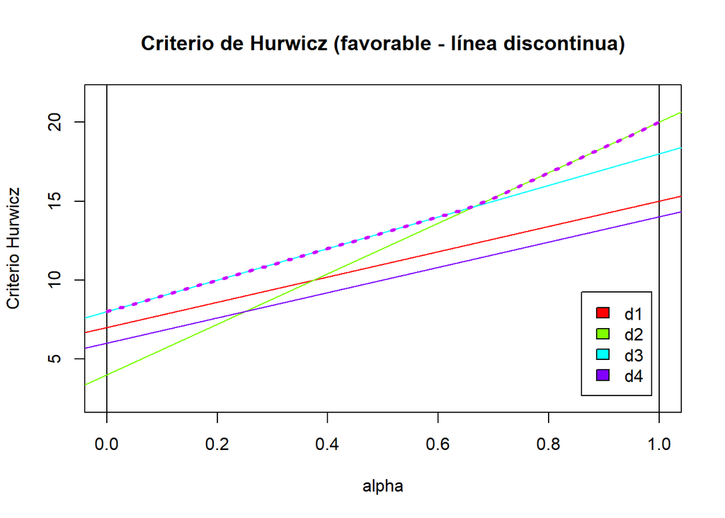

```r
# Representación gráfica y líneas de decisión
dibuja.criterio.Hurwicz(tb01, favorable = TRUE)
```

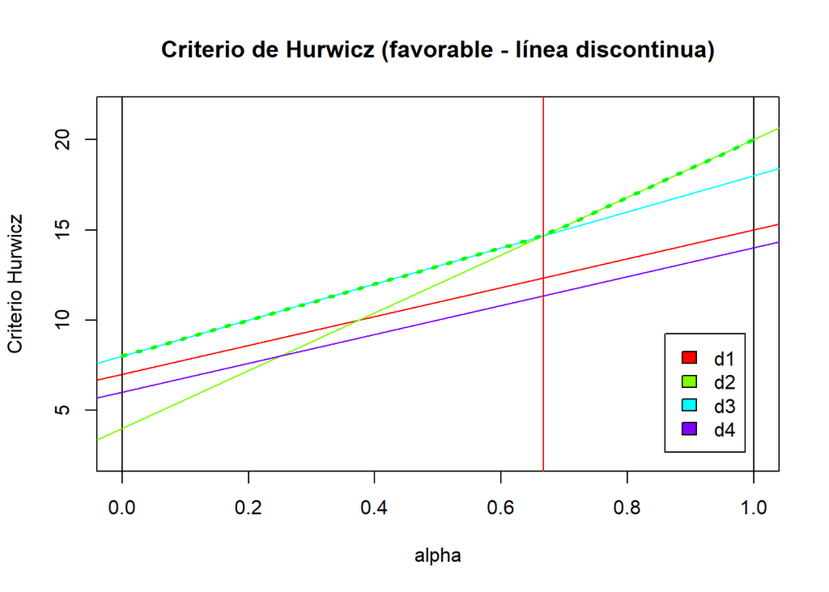

```
$AltOptimas
[1] 3 2

$PuntosDeCorte
[1] 0.667

$IntervalosAlfa
     Intervalo       Alternativa
[1,] "( 0 , 0.667 )" "3"
[2,] "( 0.667 , 1 )" "2"
```

```r
# Obtención de los puntos de intersección
dibuja.criterio.Hurwicz_Intervalos(tb01, favorable = TRUE)
```

## Resolución en Situación Desfavorable (Costes)

Ahora realizamos la resolución considerando que los valores representan costes (caso desfavorable):

```r
# 1. Criterio Pesimista (Wald / Minimax)
res_wald_des <- criterio.Wald(tb01, favorable = FALSE)
res_wald_des
```

```
$criterio
[1] "Wald"

$metodo
[1] "desfavorable"

$tablaX
   e1 e2 e3
d1 10 15  7
d2  4 20 12
d3  8  8 18
d4 12  6 14

$ValorAlternativas
d1 d2 d3 d4
15 20 18 14

$ValorOptimo
[1] 14

$AlternativaOptima
d4
 4
```

```r
# 2. Criterio Optimista
res_opt_des <- criterio.Optimista(tb01, favorable = FALSE)
res_opt_des
```

```
$criterio
[1] "Optimista"

$metodo
[1] "desfavorable"

$tablaX
   e1 e2 e3
d1 10 15  7
d2  4 20 12
d3  8  8 18
d4 12  6 14

$ValorAlternativas
d1 d2 d3 d4
 7  4  8  6

$ValorOptimo
[1] 4

$AlternativaOptima
d2
 2
```

```r
# 3. Criterio de Hurwicz (alfa = 0.4)
res_hurwicz_des <- criterio.Hurwicz(tb01, alfa = 0.4, favorable = FALSE)
res_hurwicz_des
```

```
$criterio
[1] "Hurwicz"

$alfa
[1] 0.4

$metodo
[1] "desfavorable"

$tablaX
   e1 e2 e3
d1 10 15  7
d2  4 20 12
d3  8  8 18
d4 12  6 14

$ValorAlternativas
  d1   d2   d3   d4
11.8 13.6 14.0 10.8

$ValorOptimo
[1] 10.8

$AlternativaOptima
d4
 4
```

```r
# 4. Criterio de Savage
res_savage_des <- criterio.Savage(tb01, favorable = FALSE)
res_savage_des
```

```
$criterio
[1] "Savage"

$metodo
[1] "desfavorable"

$tablaX
   e1 e2 e3
d1 10 15  7
d2  4 20 12
d3  8  8 18
d4 12  6 14

$Mejores
e1 e2 e3
 4  6  7

$Pesos
   e1 e2 e3
d1  6  9  0
d2  0 14  5
d3  4  2 11
d4  8  0  7

$ValorAlternativas
d1 d2 d3 d4
 9 14 11  8

$ValorOptimo
[1] 8

$AlternativaOptima
d4
 4
```

```r
# 5. Criterio de Laplace
res_laplace_des <- criterio.Laplace(tb01, favorable = FALSE)
res_laplace_des
```

```
$criterio
[1] "Laplace"

$metodo
[1] "desfavorable"

$tablaX
   e1 e2 e3
d1 10 15  7
d2  4 20 12
d3  8  8 18
d4 12  6 14

$ValorAlternativas
      d1       d2       d3       d4
10.66667 12.00000 11.33333 10.66667

$ValorOptimo
[1] 10.66667

$AlternativaOptima
d1 d4
 1  4
```

```r
# 6. Criterio del Punto Ideal
res_pi_des <- criterio.PuntoIdeal(tb01, favorable = FALSE)
res_pi_des
```

```
$criterio
[1] "Punto Ideal"

$metodo
[1] "desfavorable"

$tablaX
   e1 e2 e3
d1 10 15  7
d2  4 20 12
d3  8  8 18
d4 12  6 14

$Mejores
e1 e2 e3
 4  6  7

$ValorAlternativas
      d1       d2       d3       d4
10.81665 14.86607 11.87434 10.63015

$ValorOptimo
[1] 10.63015

$AlternativaOptima
d4
 4
```

### Análisis de Intervalos del Criterio de Hurwicz (Desfavorable)

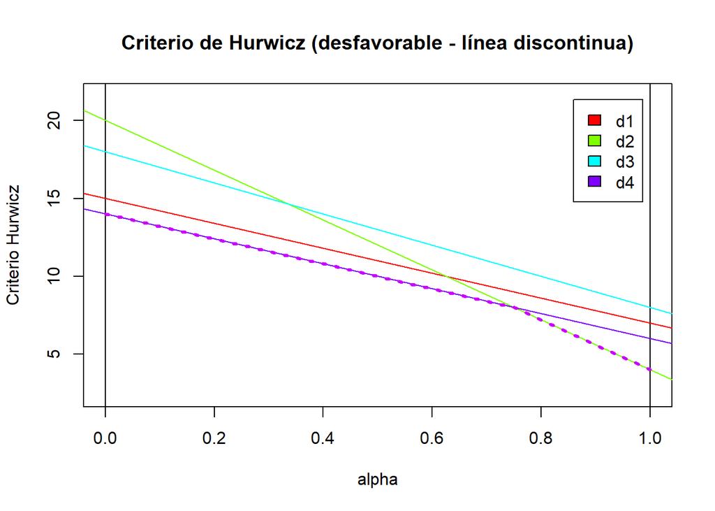

```r
# Representación gráfica y líneas de decisión
dibuja.criterio.Hurwicz(tb01, favorable = FALSE)
```

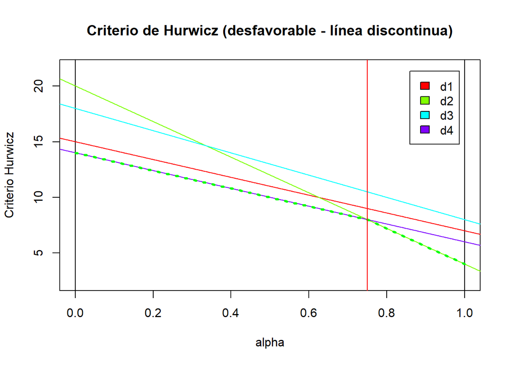

```
$AltOptimas
[1] 4 2

$PuntosDeCorte
[1] 0.75

$IntervalosAlfa
     Intervalo      Alternativa
[1,] "( 0 , 0.75 )" "4"
[2,] "( 0.75 , 1 )" "2"
```

```r
# Obtención de los puntos de intersección
dibuja.criterio.Hurwicz_Intervalos(tb01, favorable = FALSE)
```

## Justificación y Solución del Cuestionario 1

1. **Pregunta 1:** *En situación favorable (beneficios), bajo el criterio Pesimista (Wald) la alternativa óptima es $d_3$ con un valor óptimo de 8.*
   - **Verdadero.** En beneficio, los mínimos por fila son: $d_1=7, d_2=4, d_3=8, d_4=6$. El valor máximo de estos peores resultados es $8$, correspondiente a la alternativa $d_3$.
2. **Pregunta 2:** *En situación favorable, el criterio de Savage selecciona la alternativa $d_3$ como la mejor decisión.*
   - **Falso.** La matriz de arrepentimiento presenta pérdidas máximas de oportunidad por fila de: $d_1: 11, d_2: 8, d_3: 12, d_4: 14$. El menor arrepentimiento máximo es $8$, correspondiente a $d_2$.
3. **Pregunta 3:** *En situación desfavorable (costes), el criterio de Wald (Minimax) determina que la alternativa óptima es $d_4$ con un coste máximo garantizado de 14.*
   - **Verdadero.** En costes, los costes máximos por fila son: $d_1=15, d_2=20, d_3=18, d_4=14$. El menor coste máximo es $14$, alcanzado con $d_4$.
4. **Pregunta 4:** *En situación desfavorable, el criterio de Hurwicz con factor de pesimismo $\alpha=0.4$ asigna el menor coste ponderado a la alternativa $d_2$.*
   - **Falso.** Los costes ponderados con $\alpha=0.4$ son: $d_1=11.8$, $d_2=13.6$, $d_3=14.0$, $d_4=10.8$. El menor coste ponderado se obtiene con $d_4$, no con $d_2$.
5. **Pregunta 5:** *El criterio de Laplace selecciona la misma alternativa óptima ($d_2$) tanto si el problema se plantea como de beneficios como si se plantea como de costes.*
   - **Falso.** Las medias por alternativa son: $d_1=10.67$, $d_2=12.00$, $d_3=11.33$, $d_4=10.67$. En beneficios se elige el máximo ($d_2$), mientras que en costes se eligen las de menor coste medio ($d_1$ y $d_4$).

### Respuestas Verdaderas Problema 1

- **Pregunta 1:** V
- **Pregunta 2:** F
- **Pregunta 3:** V
- **Pregunta 4:** F
- **Pregunta 5:** F

# Problema 2: Aplicación en Entorno Real (“AgroTech Soluciones”)

Creamos la matriz de rendimientos económicos netos (favorable) para la empresa “AgroTech Soluciones”:

```r
vec_p2 = c(25, 20,  15,
           50, 35,  10,
           90, 40, -15,
           35, 30,  25,
           70, 45,  20)

tb02 = crea.tablaX(vec_p2,
                   numalternativas = 5,
                   numestados = 3,
                   nb_alternativas = c("Riego Inteligente", "Bioplaguicidas", "Software Predictivo", "Baterías                      BEES", "Proyecto Híbrido"),
                   nb_estados = c("Favorable", "Normal", "Adverso"))

kable(tb02, caption = "Matriz de Rendimientos Económicos Netos - AgroTech Soluciones")
```

Matriz de Rendimientos Económicos Netos - AgroTech Soluciones

|  | Favorable | Normal | Adverso |
| --- | --- | --- | --- |
| Riego Inteligente | 25 | 20 | 15 |
| Bioplaguicidas | 50 | 35 | 10 |
| Software Predictivo | 90 | 40 | -15 |
| Baterías BEES | 35 | 30 | 25 |
| Proyecto Híbrido | 70 | 45 | 20 |

## Resolución con `criterio.Todos()`

```r
res_p2_todos <- criterio.Todos(tb02, alfa = 0.4, favorable = TRUE)
kable(t(res_p2_todos), caption = "Resolución Global mediante criterio.Todos (alfa = 0.4)")
```

Resolución Global mediante criterio.Todos (alfa = 0.4)

|  | Riego Inteligente | Bioplaguicidas | Software Predictivo | Baterías BEES | Proyecto Híbrido | iAlt.Opt (fav.) |
| --- | --- | --- | --- | --- | --- | --- |
| Favorable | 25 | 50 | 90 | 35 | 70 | – |
| Normal | 20 | 35 | 40 | 30 | 45 | – |
| Adverso | 15 | 10 | -15 | 25 | 20 | – |
| Wald | 15 | 10 | -15 | 25 | 20 | Baterías BEES |
| Optimista | 25 | 50 | 90 | 35 | 70 | Software Predictivo |
| Hurwicz | 19 | 26 | 27 | 29 | 40 | Proyecto Híbrido |
| Savage | 65 | 40 | 40 | 55 | 20 | Proyecto Híbrido |
| Laplace | 20.00 | 31.67 | 38.33 | 30.00 | 45.00 | Proyecto Híbrido |
| Punto Ideal | 70.36 | 43.87 | 40.31 | 57.01 | 20.62 | Proyecto Híbrido |
| Veces Optima | 0 | 0 | 1 | 1 | 4 | Proyecto Híbrido |

### Análisis de Intervalos del Criterio de Hurwicz (Problema 2)

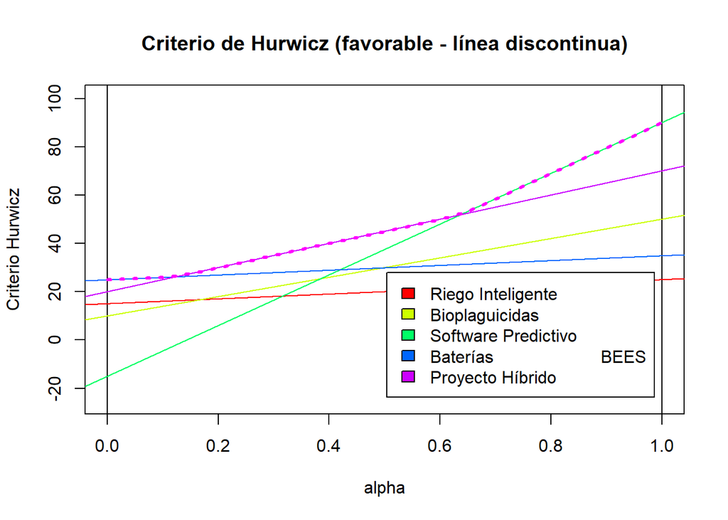

```r
# Representación gráfica y líneas de decisión
dibuja.criterio.Hurwicz(tb02, favorable = TRUE)
```

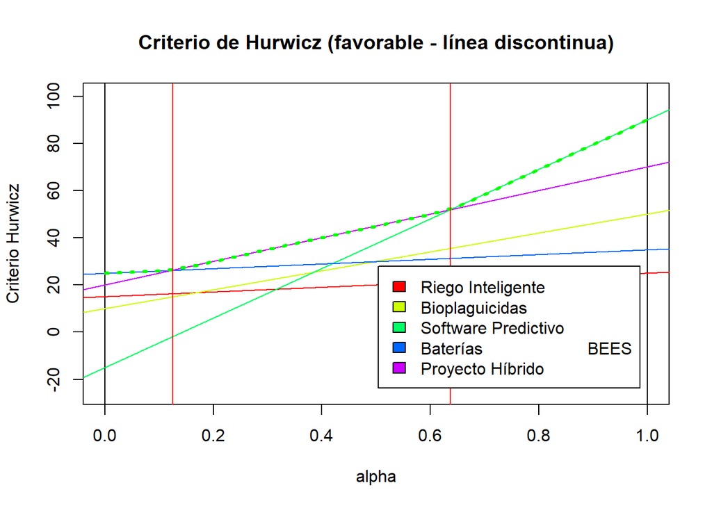

```
$AltOptimas
[1] 4 5 3

$PuntosDeCorte
[1] 0.125 0.636

$IntervalosAlfa
           Intervalo           Alternativa
Soluciones "( 0 , 0.125 )"     "4"
           "( 0.125 , 0.636 )" "5"
           "( 0.636 , 1 )"     "3"
```

```r
# Obtención de los puntos de intersección
dibuja.criterio.Hurwicz_Intervalos(tb02, favorable = TRUE)
```

## Justificación y Solución del Cuestionario 2

### Respuestas Verdaderas Problema 2

- **Pregunta 1:** V
- **Pregunta 2:** F
- **Pregunta 3:** V
- **Pregunta 4:** V
- **Pregunta 5:** F

# Problema 3: Matriz de Decisión

Construimos la matriz de decisión numéricamente definida por:

$$X = \begin{pmatrix}
1 & 7 & 3 & 0 \\
-2 & 1 & 5 & 4 \\
6 & -8 & 7 & 2 \\
-5 & 0 & 3 & -1
\end{pmatrix}$$

```r
tb03 = crea.tablaX(c(1,7,3,0,
                       -2,1,5,4,
                       6,-8,7,2,
                       -5,0,3,-1), numalternativas = 4, numestados = 4)
tb03
```

```
   e1 e2 e3 e4
d1  1  7  3  0
d2 -2  1  5  4
d3  6 -8  7  2
d4 -5  0  3 -1
```

```r
kable(tb03, caption = "Matriz de Decisiones - Problema 3")
```

Matriz de Decisiones - Problema 3

|  | e1 | e2 | e3 | e4 |
| --- | --- | --- | --- | --- |
| d1 | 1 | 7 | 3 | 0 |
| d2 | -2 | 1 | 5 | 4 |
| d3 | 6 | -8 | 7 | 2 |
| d4 | -5 | 0 | 3 | -1 |

## Resolución 3.1: Situación Favorable (Beneficios)

A continuación, aplicamos cada función individual de decisión bajo el presupuesto de que los datos representan ganancias a maximizar.

```r
# 1. Criterio de Wald (Pesimista)
sol_p3_fav_wald = criterio.Wald(tb03, favorable = TRUE)
sol_p3_fav_wald
```

```
$criterio
[1] "Wald"

$metodo
[1] "favorable"

$tablaX
   e1 e2 e3 e4
d1  1  7  3  0
d2 -2  1  5  4
d3  6 -8  7  2
d4 -5  0  3 -1

$ValorAlternativas
d1 d2 d3 d4
 0 -2 -8 -5

$ValorOptimo
[1] 0

$AlternativaOptima
d1
 1
```

```r
# 2. Criterio Optimista
sol_p3_fav_opt = criterio.Optimista(tb03, favorable = TRUE)
sol_p3_fav_opt
```

```
$criterio
[1] "Optimista"

$metodo
[1] "favorable"

$tablaX
   e1 e2 e3 e4
d1  1  7  3  0
d2 -2  1  5  4
d3  6 -8  7  2
d4 -5  0  3 -1

$ValorAlternativas
d1 d2 d3 d4
 7  5  7  3

$ValorOptimo
[1] 7

$AlternativaOptima
d1 d3
 1  3
```

```r
# 3. Criterio de Hurwicz ($\alpha = 0.5$)
sol_p3_fav_hurwicz = criterio.Hurwicz(tb03, alfa = 0.5, favorable = TRUE)
sol_p3_fav_hurwicz
```

```
$criterio
[1] "Hurwicz"

$alfa
[1] 0.5

$metodo
[1] "favorable"

$tablaX
   e1 e2 e3 e4
d1  1  7  3  0
d2 -2  1  5  4
d3  6 -8  7  2
d4 -5  0  3 -1

$ValorAlternativas
  d1   d2   d3   d4
 3.5  1.5 -0.5 -1.0

$ValorOptimo
[1] 3.5

$AlternativaOptima
d1
 1
```

```r
# 4. Criterio de Savage
sol_p3_fav_savage = criterio.Savage(tb03, favorable = TRUE)
sol_p3_fav_savage
```

```
$criterio
[1] "Savage"

$metodo
[1] "favorable"

$tablaX
   e1 e2 e3 e4
d1  1  7  3  0
d2 -2  1  5  4
d3  6 -8  7  2
d4 -5  0  3 -1

$Mejores
e1 e2 e3 e4
 6  7  7  4

$Pesos
   e1 e2 e3 e4
d1  5  0  4  4
d2  8  6  2  0
d3  0 15  0  2
d4 11  7  4  5

$ValorAlternativas
d1 d2 d3 d4
 5  8 15 11

$ValorOptimo
[1] 5

$AlternativaOptima
d1
 1
```

```r
# 5. Criterio de Laplace
sol_p3_fav_laplace = criterio.Laplace(tb03, favorable = TRUE)
sol_p3_fav_laplace
```

```
$criterio
[1] "Laplace"

$metodo
[1] "favorable"

$tablaX
   e1 e2 e3 e4
d1  1  7  3  0
d2 -2  1  5  4
d3  6 -8  7  2
d4 -5  0  3 -1

$ValorAlternativas
   d1    d2    d3    d4
 2.75  2.00  1.75 -0.75

$ValorOptimo
[1] 2.75

$AlternativaOptima
d1
 1
```

```r
# 6. Criterio del Punto Ideal
sol_p3_fav_ptoideal = criterio.PuntoIdeal(tb03, favorable = TRUE)
sol_p3_fav_ptoideal
```

```
$criterio
[1] "Punto Ideal"

$metodo
[1] "favorable"

$tablaX
   e1 e2 e3 e4
d1  1  7  3  0
d2 -2  1  5  4
d3  6 -8  7  2
d4 -5  0  3 -1

$Mejores
e1 e2 e3 e4
 6  7  7  4

$ValorAlternativas
       d1        d2        d3        d4
 7.549834 10.198039 15.132746 14.525839

$ValorOptimo
[1] 7.549834

$AlternativaOptima
d1
 1
```

### Análisis gráfico e intervalos de Hurwicz (Favorable)

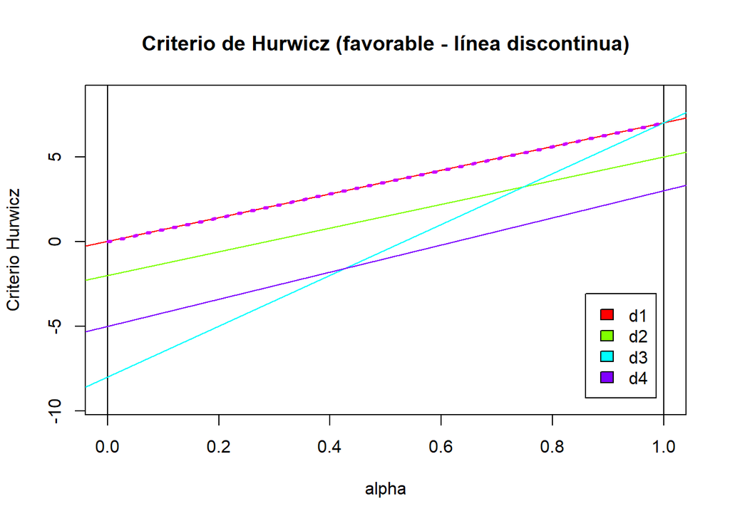

```r
# Representación gráfica y líneas de decisión
dibuja.criterio.Hurwicz(tb03, favorable = TRUE)
```

## Resolución 3.2: Situación Desfavorable (Costes)

Ahora resolvemos el problema considerando que los datos representan costes o pérdidas a minimizar.

```r
# 1. Criterio de Wald (Pesimista / Minimax )
sol_p3_des_wald = criterio.Wald(tb03, favorable = FALSE)
sol_p3_des_wald
```

```
$criterio
[1] "Wald"

$metodo
[1] "desfavorable"

$tablaX
   e1 e2 e3 e4
d1  1  7  3  0
d2 -2  1  5  4
d3  6 -8  7  2
d4 -5  0  3 -1

$ValorAlternativas
d1 d2 d3 d4
 7  5  7  3

$ValorOptimo
[1] 3

$AlternativaOptima
d4
 4
```

```r
# 2. Criterio Optimista
sol_p3_des_opt = criterio.Optimista(tb03, favorable = FALSE)
sol_p3_des_opt
```

```
$criterio
[1] "Optimista"

$metodo
[1] "desfavorable"

$tablaX
   e1 e2 e3 e4
d1  1  7  3  0
d2 -2  1  5  4
d3  6 -8  7  2
d4 -5  0  3 -1

$ValorAlternativas
d1 d2 d3 d4
 0 -2 -8 -5

$ValorOptimo
[1] -8

$AlternativaOptima
d3
 3
```

```r
# 3. Criterio de Hurwicz ($\alpha = 0.5$)
sol_p3_des_hurwicz = criterio.Hurwicz(tb03, alfa = 0.5, favorable = FALSE)
sol_p3_des_hurwicz
```

```
$criterio
[1] "Hurwicz"

$alfa
[1] 0.5

$metodo
[1] "desfavorable"

$tablaX
   e1 e2 e3 e4
d1  1  7  3  0
d2 -2  1  5  4
d3  6 -8  7  2
d4 -5  0  3 -1

$ValorAlternativas
  d1   d2   d3   d4
 3.5  1.5 -0.5 -1.0

$ValorOptimo
[1] -1

$AlternativaOptima
d4
 4
```

```r
# 4. Criterio de Savage
sol_p1_des_savage = criterio.Savage(tb03, favorable = FALSE)
sol_p1_des_savage
```

```
$criterio
[1] "Savage"

$metodo
[1] "desfavorable"

$tablaX
   e1 e2 e3 e4
d1  1  7  3  0
d2 -2  1  5  4
d3  6 -8  7  2
d4 -5  0  3 -1

$Mejores
e1 e2 e3 e4
-5 -8  3 -1

$Pesos
   e1 e2 e3 e4
d1  6 15  0  1
d2  3  9  2  5
d3 11  0  4  3
d4  0  8  0  0

$ValorAlternativas
d1 d2 d3 d4
15  9 11  8

$ValorOptimo
[1] 8

$AlternativaOptima
d4
 4
```

```r
# 5. Criterio de Laplace
sol_p3_des_laplace = criterio.Laplace(tb03, favorable = FALSE)
sol_p3_des_laplace
```

```
$criterio
[1] "Laplace"

$metodo
[1] "desfavorable"

$tablaX
   e1 e2 e3 e4
d1  1  7  3  0
d2 -2  1  5  4
d3  6 -8  7  2
d4 -5  0  3 -1

$ValorAlternativas
   d1    d2    d3    d4
 2.75  2.00  1.75 -0.75

$ValorOptimo
[1] -0.75

$AlternativaOptima
d4
 4
```

```r
# 6. Criterio del Punto Ideal
sol_p3_des_ptoideal = criterio.PuntoIdeal(tb03, favorable = FALSE)
sol_p3_des_ptoideal
```

```
$criterio
[1] "Punto Ideal"

$metodo
[1] "desfavorable"

$tablaX
   e1 e2 e3 e4
d1  1  7  3  0
d2 -2  1  5  4
d3  6 -8  7  2
d4 -5  0  3 -1

$Mejores
e1 e2 e3 e4
-5 -8  3 -1

$ValorAlternativas
      d1       d2       d3       d4
16.18641 10.90871 12.08305  8.00000

$ValorOptimo
[1] 8

$AlternativaOptima
d4
 4
```

### Análisis gráfico e intervalos de Hurwicz (Desfavorable)

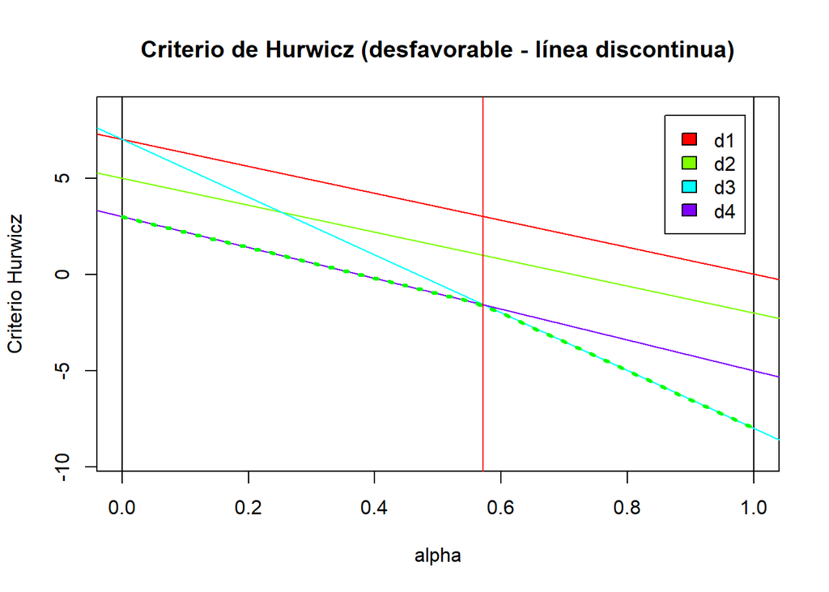

```
$AltOptimas
[1] 4 3

$PuntosDeCorte
[1] 0.571

$IntervalosAlfa
     Intervalo       Alternativa
[1,] "( 0 , 0.571 )" "4"
[2,] "( 0.571 , 1 )" "3"
```

```r
dibuja.criterio.Hurwicz_Intervalos(tb03, favorable = FALSE, mostrarGrafico = TRUE)
```

## Justificación y Solución del Cuestionario 3

# Problema 4: Caso Real (Elección de gimnasio)

Planteamos el siguiente problema considerando primero las alternativas y luego los estados de la naturaleza:

- $d_1$: gimnasio **McFit**
- $d_2$: gimnasio **Sway**
- $e_1$: Luca y Mario se van a entrenar durante **1 año**
- $e_2$: Luca y Mario no se van a entrenar más después de **6 meses**

Ahora planteamos la tabla de valoraciones:

- Alternativa $d_1$:
  - $e_1$: $30\cdot6 + 50\cdot6 = 480$ euros
  - $e_2$: $30\cdot6 + 50\cdot0 = 180$ euros
- Alternativa $d_2$:
  - $e_1$: $0\cdot1 + 40\cdot11 = 440$ euros
  - $e_2$: $0\cdot1 + 40\cdot5 = 200$ euros

```r
tb04 <- crea.tablaX(c(480, 180,
                        440, 200), numalternativas = 2, numestados = 2, nb_alternativas = c("McFit", "Sway"), nb_estados = c("1 año", "6 meses"))
kable(tb04, caption = "Matriz de Beneficios - Elección de gimnasio")
```

Matriz de Beneficios - Elección de gimnasio

|  | 1 año | 6 meses |
| --- | --- | --- |
| McFit | 480 | 180 |
| Sway | 440 | 200 |

## Resolución con `criterio.Todos()`

Vamos ahora a aplicar los criterios de decisión bajo incertidumbre para el problema planteado.

```r
res_p4_todos=criterio.Todos(tb04, alfa = 0.5, F)
kable(t(res_p4_todos), caption = "Resolución Global mediante criterio.Todos (alfa = 0.5)")
```

Resolución Global mediante criterio.Todos (alfa = 0.5)

|  | McFit | Sway | iAlt.Opt (Desfav.) |
| --- | --- | --- | --- |
| 1 año | 480 | 440 | – |
| 6 meses | 180 | 200 | – |
| Wald | 480 | 440 | Sway |
| Optimista | 180 | 200 | McFit |
| Hurwicz | 330 | 320 | Sway |
| Savage | 40 | 20 | Sway |
| Laplace | 330 | 320 | Sway |
| Punto Ideal | 40 | 20 | Sway |
| Veces Optima | 1 | 5 | Sway |

## Justificación y Solución del Cuestionario 4

# Problema 5: Matriz de Decisión (Favorable y Desfavorable)

Definimos la matriz de decisión del **Problema 5**:

```r
tb05 = crea.tablaX(c(24,19,10,16,
                        22,22,23,20,
                        23,23,21,15,
                        25,24,18,14),
                    numalternativas = 4,
                    numestados = 4)

kable(tb05, caption = "Matriz de Decisiones - Problema 5")
```

Matriz de Decisiones - Problema 5

|  | e1 | e2 | e3 | e4 |
| --- | --- | --- | --- | --- |
| d1 | 24 | 19 | 10 | 16 |
| d2 | 22 | 22 | 23 | 20 |
| d3 | 23 | 23 | 21 | 15 |
| d4 | 25 | 24 | 18 | 14 |

## Resolución en Situación Favorable (Beneficios)

A continuación resolvemos el problema mediante las funciones individuales del script para situación favorable:

```r
# 1. Criterio Pesimista (Wald)
res_wald_fav <- criterio.Wald(tb05, favorable = TRUE)
res_wald_fav
```

```
$criterio
[1] "Wald"

$metodo
[1] "favorable"

$tablaX
   e1 e2 e3 e4
d1 24 19 10 16
d2 22 22 23 20
d3 23 23 21 15
d4 25 24 18 14

$ValorAlternativas
d1 d2 d3 d4
10 20 15 14

$ValorOptimo
[1] 20

$AlternativaOptima
d2
 2
```

```r
# 2. Criterio Optimista
res_opt_fav <- criterio.Optimista(tb05, favorable = TRUE)
res_opt_fav
```

```
$criterio
[1] "Optimista"

$metodo
[1] "favorable"

$tablaX
   e1 e2 e3 e4
d1 24 19 10 16
d2 22 22 23 20
d3 23 23 21 15
d4 25 24 18 14

$ValorAlternativas
d1 d2 d3 d4
24 23 23 25

$ValorOptimo
[1] 25

$AlternativaOptima
d4
 4
```

```r
# 3. Criterio de Hurwicz (alfa = 0.6)
res_hurwicz_fav <- criterio.Hurwicz(tb05, alfa = 0.6, favorable = TRUE)
res_hurwicz_fav
```

```
$criterio
[1] "Hurwicz"

$alfa
[1] 0.6

$metodo
[1] "favorable"

$tablaX
   e1 e2 e3 e4
d1 24 19 10 16
d2 22 22 23 20
d3 23 23 21 15
d4 25 24 18 14

$ValorAlternativas
  d1   d2   d3   d4
18.4 21.8 19.8 20.6

$ValorOptimo
[1] 21.8

$AlternativaOptima
d2
 2
```

```r
# 4. Criterio de Savage
res_savage_fav <- criterio.Savage(tb05, favorable = TRUE)
res_savage_fav
```

```
$criterio
[1] "Savage"

$metodo
[1] "favorable"

$tablaX
   e1 e2 e3 e4
d1 24 19 10 16
d2 22 22 23 20
d3 23 23 21 15
d4 25 24 18 14

$Mejores
e1 e2 e3 e4
25 24 23 20

$Pesos
   e1 e2 e3 e4
d1  1  5 13  4
d2  3  2  0  0
d3  2  1  2  5
d4  0  0  5  6

$ValorAlternativas
d1 d2 d3 d4
13  3  5  6

$ValorOptimo
[1] 3

$AlternativaOptima
d2
 2
```

```r
# 5. Criterio de Laplace
res_laplace_fav <- criterio.Laplace(tb05, favorable = TRUE)
res_laplace_fav
```

```
$criterio
[1] "Laplace"

$metodo
[1] "favorable"

$tablaX
   e1 e2 e3 e4
d1 24 19 10 16
d2 22 22 23 20
d3 23 23 21 15
d4 25 24 18 14

$ValorAlternativas
   d1    d2    d3    d4
17.25 21.75 20.50 20.25

$ValorOptimo
[1] 21.75

$AlternativaOptima
d2
 2
```

```r
# 6. Criterio del Punto Ideal
res_pi_fav <- criterio.PuntoIdeal(tb05, favorable = TRUE)
res_pi_fav
```

```
$criterio
[1] "Punto Ideal"

$metodo
[1] "favorable"

$tablaX
   e1 e2 e3 e4
d1 24 19 10 16
d2 22 22 23 20
d3 23 23 21 15
d4 25 24 18 14

$Mejores
e1 e2 e3 e4
25 24 23 20

$ValorAlternativas
       d1        d2        d3        d4
14.525839  3.605551  5.830952  7.810250

$ValorOptimo
[1] 3.605551

$AlternativaOptima
d2
 2
```

### Análisis de Intervalos del Criterio de Hurwicz (Favorable)

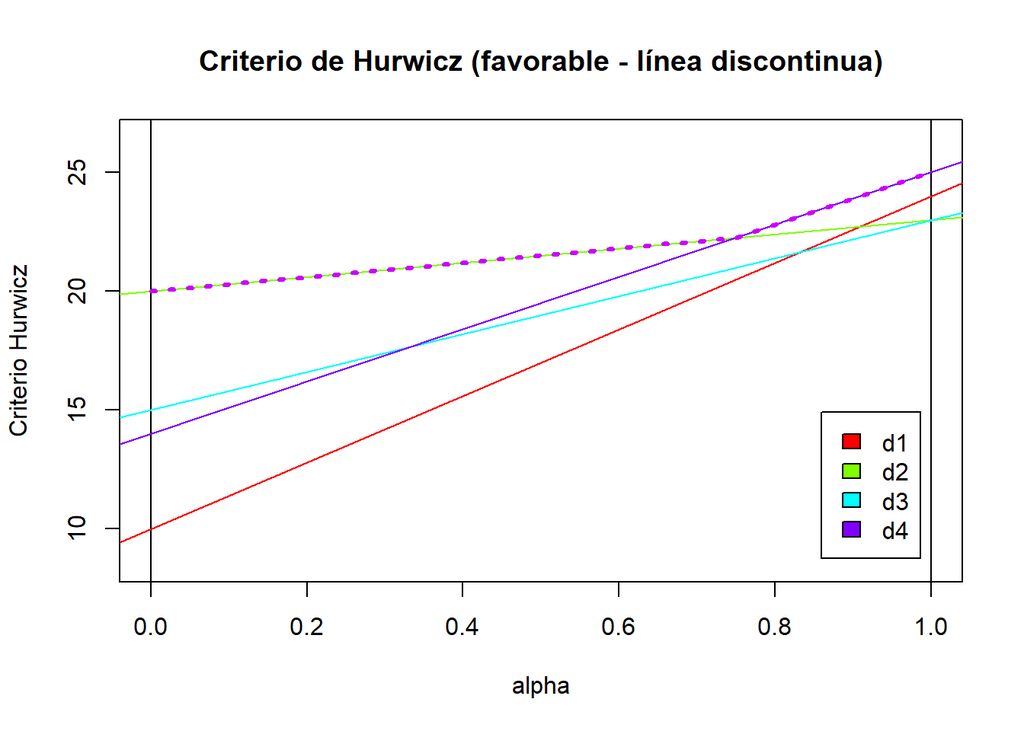

```r
# Representación gráfica y líneas de decisión
dibuja.criterio.Hurwicz(tb05, favorable = TRUE)
```

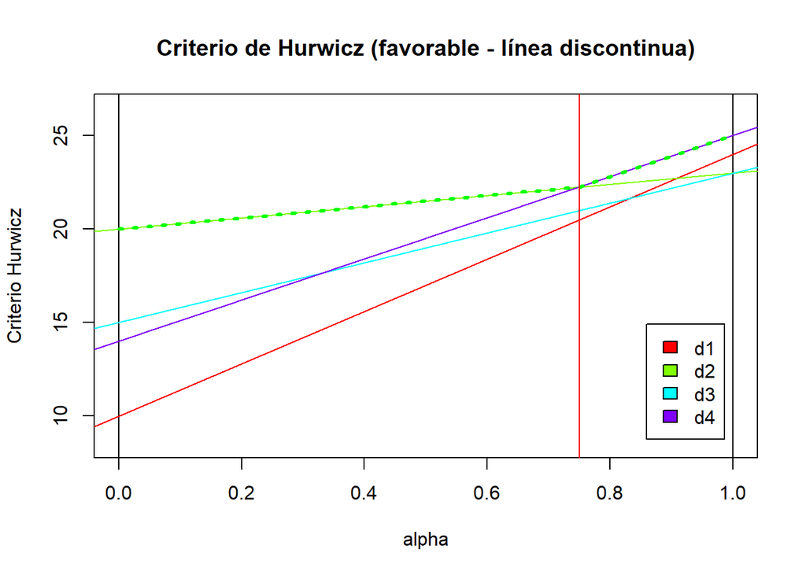

```
$AltOptimas
[1] 2 4

$PuntosDeCorte
[1] 0.75

$IntervalosAlfa
     Intervalo      Alternativa
[1,] "( 0 , 0.75 )" "2"
[2,] "( 0.75 , 1 )" "4"
```

```r
# Obtención de los puntos de intersección
dibuja.criterio.Hurwicz_Intervalos(tb05, favorable = TRUE)
```

## Resolución en Situación Desfavorable (Costes)

Ahora realizamos la resolución considerando que los valores representan costes (caso desfavorable):

```r
# 1. Criterio Pesimista (Wald)
res_wald_des <- criterio.Wald(tb05, favorable = FALSE)
res_wald_des
```

```
$criterio
[1] "Wald"

$metodo
[1] "desfavorable"

$tablaX
   e1 e2 e3 e4
d1 24 19 10 16
d2 22 22 23 20
d3 23 23 21 15
d4 25 24 18 14

$ValorAlternativas
d1 d2 d3 d4
24 23 23 25

$ValorOptimo
[1] 23

$AlternativaOptima
d2 d3
 2  3
```

```r
# 2. Criterio Optimista
res_opt_des <- criterio.Optimista(tb05, favorable = FALSE)
res_opt_des
```

```
$criterio
[1] "Optimista"

$metodo
[1] "desfavorable"

$tablaX
   e1 e2 e3 e4
d1 24 19 10 16
d2 22 22 23 20
d3 23 23 21 15
d4 25 24 18 14

$ValorAlternativas
d1 d2 d3 d4
10 20 15 14

$ValorOptimo
[1] 10

$AlternativaOptima
d1
 1
```

```r
# 3. Criterio de Hurwicz (alfa = 0.6)
res_hurwicz_des <- criterio.Hurwicz(tb05, alfa = 0.6, favorable = FALSE)
res_hurwicz_des
```

```
$criterio
[1] "Hurwicz"

$alfa
[1] 0.6

$metodo
[1] "desfavorable"

$tablaX
   e1 e2 e3 e4
d1 24 19 10 16
d2 22 22 23 20
d3 23 23 21 15
d4 25 24 18 14

$ValorAlternativas
  d1   d2   d3   d4
15.6 21.2 18.2 18.4

$ValorOptimo
[1] 15.6

$AlternativaOptima
d1
 1
```

```r
# 4. Criterio de Savage
res_savage_des <- criterio.Savage(tb05, favorable = FALSE)
res_savage_des
```

```
$criterio
[1] "Savage"

$metodo
[1] "desfavorable"

$tablaX
   e1 e2 e3 e4
d1 24 19 10 16
d2 22 22 23 20
d3 23 23 21 15
d4 25 24 18 14

$Mejores
e1 e2 e3 e4
22 19 10 14

$Pesos
   e1 e2 e3 e4
d1  2  0  0  2
d2  0  3 13  6
d3  1  4 11  1
d4  3  5  8  0

$ValorAlternativas
d1 d2 d3 d4
 2 13 11  8

$ValorOptimo
[1] 2

$AlternativaOptima
d1
 1
```

```r
# 5. Criterio de Laplace
res_laplace_des <- criterio.Laplace(tb05, favorable = FALSE)
res_laplace_des
```

```
$criterio
[1] "Laplace"

$metodo
[1] "desfavorable"

$tablaX
   e1 e2 e3 e4
d1 24 19 10 16
d2 22 22 23 20
d3 23 23 21 15
d4 25 24 18 14

$ValorAlternativas
   d1    d2    d3    d4
17.25 21.75 20.50 20.25

$ValorOptimo
[1] 17.25

$AlternativaOptima
d1
 1
```

```r
# 6. Criterio del Punto Ideal
res_pi_des <- criterio.PuntoIdeal(tb05, favorable = FALSE)
res_pi_des
```

```
$criterio
[1] "Punto Ideal"

$metodo
[1] "desfavorable"

$tablaX
   e1 e2 e3 e4
d1 24 19 10 16
d2 22 22 23 20
d3 23 23 21 15
d4 25 24 18 14

$Mejores
e1 e2 e3 e4
22 19 10 14

$ValorAlternativas
       d1        d2        d3        d4
 2.828427 14.628739 11.789826  9.899495

$ValorOptimo
[1] 2.828427

$AlternativaOptima
d1
 1
```

### Análisis de Intervalos del Criterio de Hurwicz (Desfavorable)

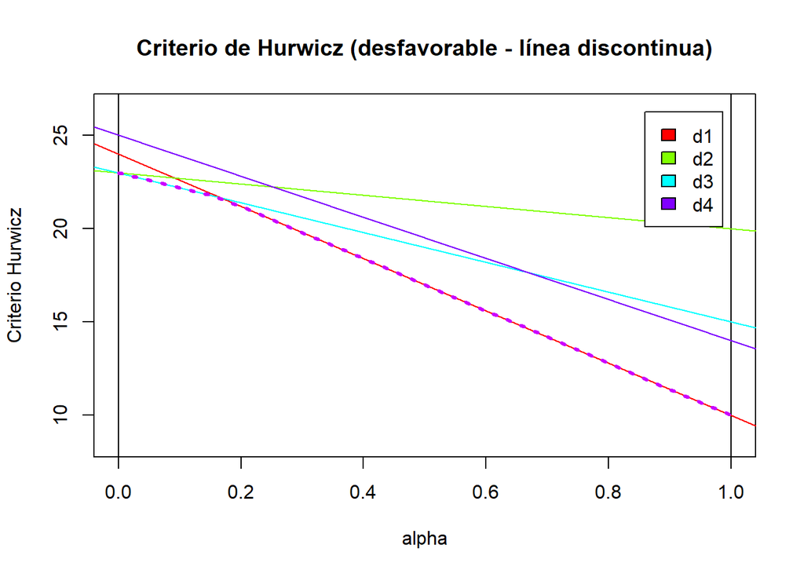

```r
# Representación gráfica y líneas de decisión
dibuja.criterio.Hurwicz(tb05, favorable = FALSE)
```

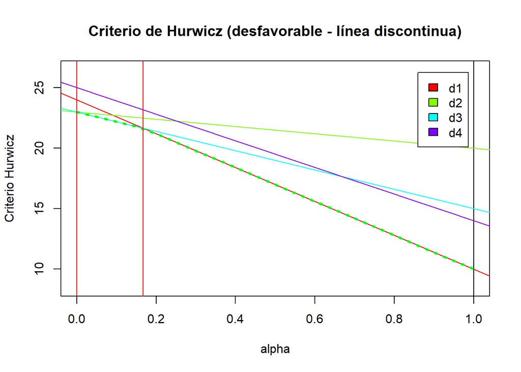

```
$AltOptimas
[1] 2 3 1

$PuntosDeCorte
[1] 0.000 0.167

$IntervalosAlfa
           Intervalo       Alternativa
Soluciones "( 0 , 0 )"     "2"
           "( 0 , 0.167 )" "3"
           "( 0.167 , 1 )" "1"
```

```r
# Obtención de los puntos de intersección
dibuja.criterio.Hurwicz_Intervalos(tb05, favorable = FALSE)
```

## Justificación y Solución del Cuestionario 5

1. **Pregunta 1:** *Según el Criterio Pesimista, en situación desfavorable, la alternativa óptima es la primera: $d_1$.*
   - **Falso**. En situación desfavorable, según este criterio hay dos alternativas óptimas, la segunda $d_2$: y la tercera: $d_3$.
2. **Pregunta 2:** *Aplicando el Criterio Optimista, en situación favorable, la alternativa seleccionada corresponde a la tercera: $d_3$.*
   - **Falso**. En situación favorable, según este criterio la alternativa óptima es la cuarta: $d_4$.
3. **Pregunta 3:** *Utilizando el Criterio de Laplace, en situación desfavorable, la alternativa que presenta mayor valor de esperanza matemática, y por tanto es la óptima, es la segunda: $d_2$.*
   - **Falso**. En situación desfavorable, según este criterio la alternativa óptima es la primera: $d_1$, la alternativa que presenta **menor** valor de esperanza matemática.
4. **Pregunta 4:** *El valor mínimo absoluto contenido en toda la matriz de decisión de la tabla es 14.*
   - **Falso**. El valor mínimo absoluto contenido en toda la matriz de decisión de la tabla es 10.
5. **Pregunta 5:** *Si se aplica el Criterio de Hurwicz, en situación favorable, con un coeficiente de optimismo $\alpha = 0,6$, el valor ponderado obtenido para la cuarta fila es 20,6.*
   - **Verdadero**. Basta con irse a las salidas de la función `criterio.Hurwicz()` para comprobarlo.

### Respuestas Verdaderas Problema 5

- **Pregunta 1:** F
- **Pregunta 2:** F
- **Pregunta 3:** F
- **Pregunta 4:** F
- **Pregunta 5:** V

# Problema 6: Aplicación en Entorno Real (Ingresos tutor para el próximo cuatrimestre)

Planteamos la matriz de decisión del **Problema 6** considerando los ingresos del tutor para el próximo cuatrimestre:

```r
tb06 = crea.tablaX(c(1440,1200,750,
                     2500,1400,400,
                     3000,800,-200),
                    numalternativas = 3,
                    numestados = 3,
                   nb_alternativas = c("Clases individuales","Talleres intensivos","Material digital"),
                   nb_estados = c("Alta","Moderada","Baja"))

kable(tb06, caption = "Matriz de Beneficios Netos")
```

Matriz de Beneficios Netos

|  | Alta | Moderada | Baja |
| --- | --- | --- | --- |
| Clases individuales | 1440 | 1200 | 750 |
| Talleres intensivos | 2500 | 1400 | 400 |
| Material digital | 3000 | 800 | -200 |

## Resolución con `criterio.Todos()`

```r
res_p6_todos <- criterio.Todos(tb06, alfa = 0.5, favorable = TRUE)
colnames(res_p6_todos) <- c("Alta", "Mod", "Baja", "Wald", "Opt", "Hurw", "Savage", "Laplace", "P.Ideal", "Optima")
kable(t(res_p6_todos), caption = "Resolución Global mediante criterio.Todos (alfa = 0.5)")
```

Resolución Global mediante criterio.Todos (alfa = 0.5)

|  | Clases individuales | Talleres intensivos | Material digital | iAlt.Opt (fav.) |
| --- | --- | --- | --- | --- |
| Alta | 1440 | 2500 | 3000 | – |
| Mod | 1200 | 1400 | 800 | – |
| Baja | 750 | 400 | -200 | – |
| Wald | 750 | 400 | -200 | Clases individuales |
| Opt | 1440 | 2500 | 3000 | Material digital |
| Hurw | 1095 | 1450 | 1400 | Talleres intensivos |
| Savage | 1560 | 500 | 950 | Talleres intensivos |
| Laplace | 1130 | 1433 | 1200 | Talleres intensivos |
| P.Ideal | 1572.8 | 610.3 | 1123.6 | Talleres intensivos |
| Optima | 1 | 4 | 1 | Talleres intensivos |

### Análisis de Intervalos del Criterio de Hurwicz (Problema 6)

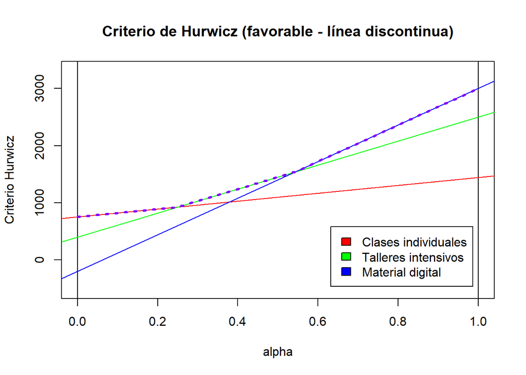

```r
# Representación gráfica y líneas de decisión
dibuja.criterio.Hurwicz(tb06, favorable = TRUE)
```

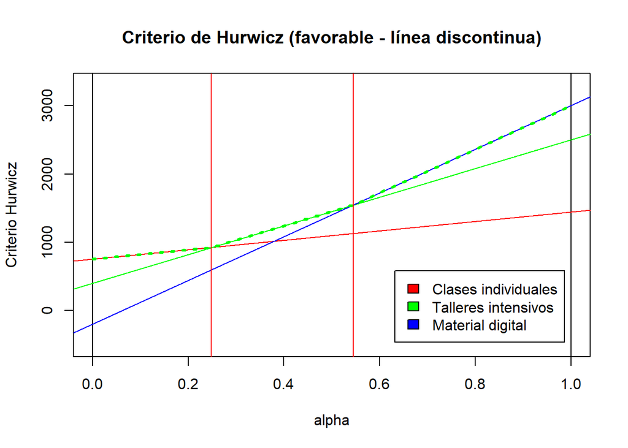

```
$AltOptimas
[1] 1 2 3

$PuntosDeCorte
[1] 0.248 0.545

$IntervalosAlfa
           Intervalo           Alternativa
Soluciones "( 0 , 0.248 )"     "1"
           "( 0.248 , 0.545 )" "2"
           "( 0.545 , 1 )"     "3"
```

```r
# Obtención de los puntos de intersección
dibuja.criterio.Hurwicz_Intervalos(tb06, favorable = TRUE)
```

Debido a que con los 6 criterios realizados, la alternativa más veces óptima ($4/6$) es la de **Talleres Intensivos**, al tutor le recomendaría esa alternativa.

## Justificación y Solución del Cuestionario 6

1. **Pregunta 1:** *Según el Criterio de Wald, la alternativa óptima para el tutor son las Clases individuales ($d_1$).*
   - **Verdadero**. Basta con ver la salida del criterio Wald.
2. **Pregunta 2:** *Aplicando el Criterio optimista, la alternativa seleccionada es la de los Talleres intensivos ($d_2$).*
   - **Falso**. La opción con el mayor beneficio máximo es la de *Material digital* $d_3$ con 3.000€).
3. **Pregunta 3:** *Utilizando el Criterio de Laplace, el valor de la esperanza matemática para los Talleres intensivos ($d_2$) es superior a 1.400€.*
   - **Verdadero**. El valor de la esperanza matemática para los *Talleres intensivos* ($d_2$) es de 1.433,33€.
4. **Pregunta 4:** *El coste de oportunidad máximo (arrepentimiento) para la alternativa de Material digital ($d_3$) bajo el Criterio de Savage es de 600€.*
   - **Falso**. El coste de oportunidad máximo (arrepentimiento) para la alternativa de *Material digital* ($d_3$) bajo el criterio de Savage es de 950€.
5. **Pregunta 5:** *Si se aplica el Criterio de Hurwicz con un coeficiente de optimismo $\alpha = 0.5$, la alternativa preferida es la de Material digital ($d_3$).*
   - **Falso**, la alternativa preferida es la de *Talleres intensivos* ($d_2$) con un valor ponderado de 1.450€.

### Respuestas Verdaderas Problema 6

- **Pregunta 1:** V
- **Pregunta 2:** F
- **Pregunta 3:** V
- **Pregunta 4:** F
- **Pregunta 5:** F